# HW07

Noah Dunn

November 17, 2018

### 1.

```r
clintonData <- read.csv("election1992.csv")
clintonData <- clintonData %>%
  mutate(Q1 = quantile(Percent,0.25),
         Q3 = quantile(Percent,0.75))
cleanClintonData <- clintonData %>%
  filter(Percent > Q1 & Percent < Q3)
```

### 2.

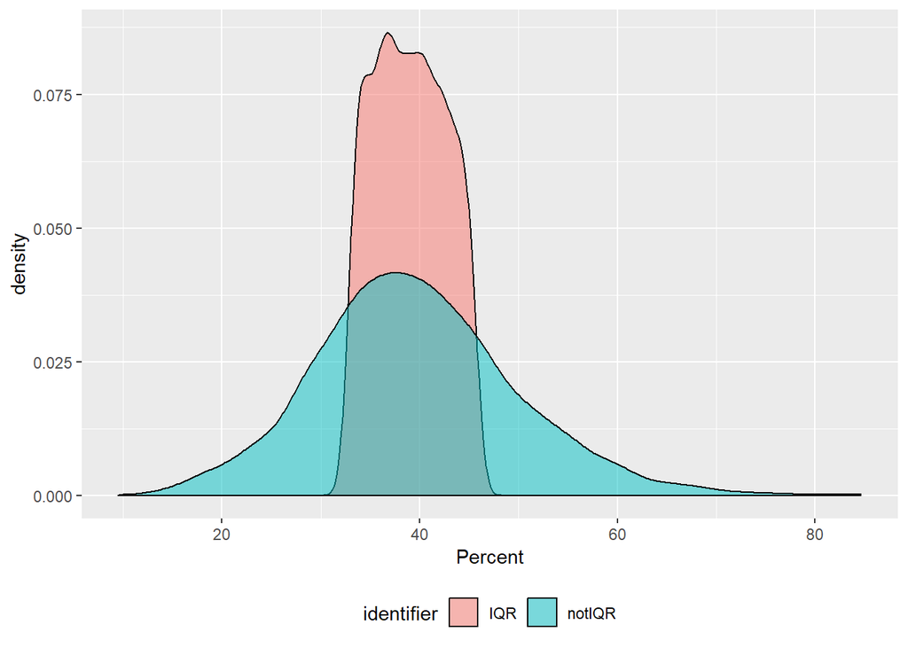

```r
clintonData$identifier <- 'notIQR'
cleanClintonData$identifier <- 'IQR'
graphData <- rbind(clintonData, cleanClintonData)
ggplot(graphData)+
  geom_density(aes(x=Percent, fill = identifier), alpha=0.5)+
  theme(legend.position="bottom")
```

For the plot that contains all the data, the density of percentage voting appears about normal with a large density conentration at around 40 Perceent with a Density close to 0.045. The IQR plot on the other hand has a very small range of percentages (35 ~ 45) with all the density falling in this range close to 0.085.

### 3.

```r
full.fit <- lm(Percent ~ Age + Savings + Income + Poverty + Veterans + Female + Population + Nursing + Crime, data = cleanClintonData)
step.pick.backward <- step(full.fit, direction="backward")
```

```
## Start:  AIC=3386.27
## Percent ~ Age + Savings + Income + Poverty + Veterans + Female +
##     Population + Nursing + Crime
##
##              Df Sum of Sq   RSS    AIC
## - Savings     1     21.85 16326 3386.1
## <none>                    16304 3386.3
## - Nursing     1     24.57 16329 3386.3
## - Income      1     25.43 16330 3386.4
## - Crime       1     32.25 16336 3386.9
## - Age         1     65.85 16370 3389.7
## - Veterans    1     73.52 16378 3390.3
## - Female      1    166.63 16471 3398.0
## - Population  1    203.77 16508 3401.1
## - Poverty     1    338.39 16643 3412.0
##
## Step:  AIC=3386.08
## Percent ~ Age + Income + Poverty + Veterans + Female + Population +
##     Nursing + Crime
##
##              Df Sum of Sq   RSS    AIC
## - Income      1     13.07 16339 3385.2
## <none>                    16326 3386.1
## - Crime       1     40.46 16367 3387.4
## - Nursing     1     44.05 16370 3387.7
## - Age         1     60.01 16386 3389.0
## - Veterans    1     80.46 16407 3390.7
## - Population  1    188.26 16514 3399.6
## - Female      1    188.48 16515 3399.6
## - Poverty     1    354.53 16681 3413.1
##
## Step:  AIC=3385.16
## Percent ~ Age + Poverty + Veterans + Female + Population + Nursing +
##     Crime
##
##              Df Sum of Sq   RSS    AIC
## <none>                    16339 3385.2
## - Nursing     1     40.95 16380 3386.5
## - Crime       1     57.76 16397 3387.9
## - Age         1     59.94 16399 3388.1
## - Veterans    1     74.99 16414 3389.3
## - Female      1    178.04 16517 3397.8
## - Population  1    178.09 16517 3397.8
## - Poverty     1    718.10 17057 3441.3
```

```r
summary(step.pick.backward)
```

```
##
## Call:
## lm(formula = Percent ~ Age + Poverty + Veterans + Female + Population +
##     Nursing + Crime, data = cleanClintonData)
##
## Residuals:
##     Min      1Q  Median      3Q     Max
## -7.6296 -2.7578 -0.0429  2.8035  7.8259
##
## Coefficients:
##               Estimate Std. Error t value Pr(>|t|)
## (Intercept) 24.5203291  3.3189721   7.388 2.61e-13 ***
## Age         -0.0752323  0.0338807  -2.221 0.026551 *
## Poverty      0.1468282  0.0191044   7.686 2.92e-14 ***
## Veterans     0.1288725  0.0518877   2.484 0.013124 *
## Female       0.2575688  0.0673060   3.827 0.000136 ***
## Population   0.0027713  0.0007241   3.827 0.000135 ***
## Nursing      0.0354039  0.0192912   1.835 0.066691 .
## Crime       -0.0011823  0.0005424  -2.180 0.029449 *
## ---
## Signif. codes:  0 '***' 0.001 '**' 0.01 '*' 0.05 '.' 0.1 ' ' 1
##
## Residual standard error: 3.487 on 1344 degrees of freedom
## Multiple R-squared:  0.06696,    Adjusted R-squared:  0.0621
## F-statistic: 13.78 on 7 and 1344 DF,  p-value: < 2.2e-16
```

set.seed(66666)

```r
train_control <- trainControl(method="cv", number=10)
ptm <- proc.time()
train.choochoo <- train(Percent ~ Age + Savings + Income + Poverty + Veterans + Female + Population + Nursing + Crime, data= cleanClintonData, trControl=train_control, method="lm")
```

```r
train_control <- trainControl(method="cv", number=10)
train.choochoochoo <- train(Percent ~ Poverty + Veterans + Female + Population + Nursing + Crime + Age, data= cleanClintonData, trControl=train_control, method="lm")
print(proc.time() - ptm)
```

```
##    user  system elapsed
##    1.09    0.06    1.15
```

```r
results10 <- resamples(list(Mod1 = train.choochoo, Mod2= train.choochoochoo ))
```

## 4.

set.seed(66666)

```r
train_control <- trainControl(method="cv", number=500)
ptm <- proc.time()
train.choochoo <- train(Percent ~ Age + Savings + Income + Poverty + Veterans + Female + Population + Nursing + Crime, data= cleanClintonData, trControl=train_control, method="lm")
```

```r
train_control <- trainControl(method="cv", number=500)
train.choochoochoo <- train(Percent ~ Poverty + Veterans + Female + Population + Nursing + Crime + Age, data= cleanClintonData, trControl=train_control, method="lm")
print(proc.time() - ptm)
```

```
##    user  system elapsed
##    6.58    0.03    6.62
```

```r
results500 <- resamples(list(Mod1 = train.choochoo, Mod2= train.choochoochoo ))
```

## 5.

```r
summary(results10)
```

```
##
## Call:
## summary.resamples(object = results10)
##
## Models: Mod1, Mod2
## Number of resamples: 10
##
## MAE
##          Min.  1st Qu.   Median     Mean  3rd Qu.     Max. NA's
## Mod1 2.851488 2.950015 2.983108 2.978469 3.015022 3.121208    0
## Mod2 2.876869 2.939010 2.978114 2.977737 3.036500 3.068319    0
##
## RMSE
##          Min.  1st Qu.   Median     Mean  3rd Qu.     Max. NA's
## Mod1 3.350450 3.408360 3.499428 3.493337 3.548818 3.709514    0
## Mod2 3.376307 3.472609 3.505104 3.491753 3.524764 3.558064    0
##
## Rsquared
##             Min.    1st Qu.     Median       Mean    3rd Qu.      Max.
## Mod1 0.004749041 0.04715532 0.07213111 0.06991298 0.09891201 0.1430137
## Mod2 0.015807373 0.04391980 0.06337728 0.06387632 0.07789304 0.1410187
##      NA's
## Mod1    0
## Mod2    0
```

```r
summary(results500)
```

```
##
## Call:
## summary.resamples(object = results500)
##
## Models: Mod1, Mod2
## Number of resamples: 500
##
## MAE
##           Min.  1st Qu.  Median     Mean  3rd Qu.     Max. NA's
## Mod1 0.2556569 2.150694 2.99735 2.973624 3.732188 5.871998    0
## Mod2 0.3702134 2.203417 2.89866 2.991755 3.733260 6.353118    0
##
## RMSE
##           Min.  1st Qu.  Median     Mean  3rd Qu.     Max. NA's
## Mod1 0.2556657 2.561810 3.38872 3.309023 4.175505 5.941629    0
## Mod2 0.4614119 2.600168 3.34407 3.327234 4.134353 6.397328    0
##
## Rsquared
##              Min.   1st Qu.    Median      Mean 3rd Qu. Max. NA's
## Mod1 8.425696e-05 0.2722635 0.8109915 0.6504938       1    1    0
## Mod2 3.407483e-06 0.3579519 0.8561951 0.6787414       1    1    0
```

Although the 500 fold cross-validation takes almost 6 times longer than the 10 fold cross-validation, the R-Squared value for the particular seed I used on my particular machine went from around 0.06 for both models on the 10 fold validation to around 0.65 on the 500 fold validation. The 10 fold is much faster, but the 500 fold is a much more predictive model with a higher R-squared.

## 6.

Using my particular seed, the full model proved to have a higher R-Squared with the 10-fold, and the backwards-prediction model proved to have a higher R-Squared with the 500-fold. However, given that it is likely one would want to use the fold technique with a much larger R-Squared output, the second model, or the model that selected according to backwards selection is likely preferable to the one that just included everything.